# Implementation of YOLO object detection using OpenCV

I implemented YOLO v3 object detection model using OpenCV.

- YOLO v3 : weights file and config file are downloaded by following the instruction described in https://pjreddie.com/darknet/yolo/
- OpenCV 3.4.2
- Numpy 1.14.3

Tutorial: https://www.pyimagesearch.com/2018/11/12/yolo-object-detection-with-opencv/

```python
import numpy as np
import cv2
from matplotlib import pyplot as plt

%matplotlib inline
```

```python
print("OpenCV version {}".format(cv2.__version__))
print("numpy version {}".format(np.__version__))
```

```
OpenCV version 3.4.2
numpy version 1.14.3
```

```python
# set filenames to read
coco_names_file = "yolo/coco.names"
yolov3_weight_file = "yolo/yolov3.weights"
yolov3_config_file = "yolo/yolov3.cfg"

# read coco object names
LABELS = open(coco_names_file).read().strip().split("\n")

# assign rondom colours to the corresponding class labels
np.random.seed(45)
COLORS = np.random.randint(0, 255, size=(len(LABELS), 3), dtype="uint8")

# read YOLO network model
net = cv2.dnn.readNetFromDarknet(yolov3_config_file, yolov3_weight_file)
```

```python
# read image file
# image is an array of image data (row, column, channel)

image = cv2.imread("images/perth.jpg")

(h, w) = image.shape[:2]

# preprocess image data with rescaling and resizing
# OpenCV assumes BGR images: we have to convert to RGB, with swapRB=True
blob = cv2.dnn.blobFromImage(image, 1 / 255.0, (416, 416), swapRB=True, crop=False)

# set a new input to the network
net.setInput(blob)
```

```python
# print the information of layers in YOLO v3 model

# get all layer names in the network
ln = net.getLayerNames()
print("--- Layers in YOLO v3 ---")
print(ln)
print("--- {} layers ---".format(len(ln)))

# this is indices of layers with unconnected output
print("\nIndices of YOLO v3 output layers = \n{}".format(net.getUnconnectedOutLayers()))

# get layers only with unconnected output
ln_out = [ln[i[0] - 1] for i in net.getUnconnectedOutLayers()]
print("Names of YOLO v3 output layers = {}".format(ln_out))
```

```
--- Layers in YOLO v3 ---
['conv_0', 'bn_0', 'relu_0', 'conv_1', 'bn_1', 'relu_1', 'conv_2', 'bn_2', 'relu_2', 'conv_3', 'bn_3', 'relu_3', 'shortcut_4', 'conv_5', 'bn_5', 'relu_5', 'conv_6', 'bn_6', 'relu_6', 'conv_7', 'bn_7', 'relu_7', 'shortcut_8', 'conv_9', 'bn_9', 'relu_9', 'conv_10', 'bn_10', 'relu_10', 'shortcut_11', '…
--- 254 layers ---

Indices of YOLO v3 output layers =
[[200]
 [227]
 [254]]
Names of YOLO v3 output layers = ['yolo_82', 'yolo_94', 'yolo_106']
```

```python
# perform object detection
layerOutputs = net.forward(ln_out)
```

```python
# print the shape of output
print(np.array(layerOutputs)[0].shape)
print(np.array(layerOutputs)[1].shape)
print(np.array(layerOutputs)[2].shape)
print(layerOutputs[0])
```

```
(507, 85)
(2028, 85)
(8112, 85)
[[0.04206767 0.04696063 0.4795163  ... 0.         0.         0.        ]
 [0.0432005  0.03772499 0.30951595 ... 0.         0.         0.        ]
 [0.04506741 0.04035927 0.79257333 ... 0.         0.         0.        ]
 ...
 [0.95698696 0.9519735  0.39555147 ... 0.         0.         0.        ]
 [0.9632255  0.9660053  0.29263413 ... 0.         0.         0.        ]
 [0.9668853  0.9641262  0.8724485  ... 0.         0.         0.        ]]
```

**NOTE:**

Underlying architecture for YOLO v3 comes from Darknet, which has 106 layers in terms of network architecture. The characteristic of YOLO v3 is that it has three output layers: the detection is done by applying 1 x 1 detection kernels on feature maps of three different sizes at three different places in the network.

Above output shows layer 200 (`'yolo_82'`), layer 227 (`'yolo_94'`), and layer 254 (`'yolo_106'`) are the output layers. These layer apply 1 x 1 convolution on input.

The number of attributes included in the kernel is:

$$(B \times (5 + C))$$

where:

- B = 3, the number of the bounding box (anchor box)
- C = 80, the number of classes in COCO
- 5 = (x, y, width, height, object confidence)

For each output layer:

- 1st output layer (`'yolo_82'`): input shape = 13 x 13 ---> (13 x 13 x 3, 85) = (507, 85)
- 2nd output layer (`'yolo_94'`): input shape = 26 x 26 ---> (26 x 26 x 3, 85) = (2028, 85)
- 3rd output layer (`'yolo_106'`): input shape = 52 x 52 ---> (52 x 52 x 3, 85) = (8112, 85)

1st output layer(detect **BIGGER OBJECTS**) ---> 2nd output layer ---> 3rd output layer (detect **SMALLER OBJECTS**)

*Reference:* https://towardsdatascience.com/yolo-v3-object-detection-53fb7d3bfe6b

**NOTE2:**

In YOLO v3, each class is seperately predicted using **logistic regression** instead of *softmax*. This allows the model to predict, for example, the image of a woman as 'person' and as 'woman' at the same time.

**NOTE3:**

There is a case that the box confidence for a box is high enough with all class probabilities are 0.

```python
# Filter objects with the lower (box confidence * class prediction probability) than the threshold

threshold = 0.5

boxes = []
scores = []
classes = []

for output in layerOutputs:

    box_xywh = np.array(output[:, :4])
    box_confidence = np.array(output[:, 4]).reshape(output.shape[0], 1)
    box_class_probs = np.array(output[:, 5:])

    #print("box_xywh = {}".format(box_xywh[0]))
    #print("box_confidence = {}".format(np.squeeze(box_confidence, axis=1)))

    box_scores = box_confidence * box_class_probs
    box_class = np.argmax(box_scores, axis=-1)
    box_class_scores = np.max(box_scores, axis=-1)
    #print("box_confidence = {}, box_class = {}, box_class_scores = {}, box_class_probs={}".format(box_confidence[289],
    #                                                                          box_class[289], box_class_scores[289],
    #                                                                            box_class_probs[289]))

    # pick up boxes with box_class_scores which are higher than threshold
    filtering_mask = box_class_scores >= threshold
    #filtering_mask = np.squeeze(box_confidence, axis=1)  >= threshold
    class_filtered = box_class[filtering_mask]
    score_filtered = box_class_scores[filtering_mask]
    xywh_filtered = box_xywh[np.nonzero(filtering_mask)]

    #print("class_filtered = {}".format(class_filtered))
    #print("score_filtered = {}".format(score_filtered))
    #print("xywh_filtered = {}".format(xywh_filtered))
    #print("filtering_mask = {}, len={}".format(filtering_mask, len(filtering_mask)))

    boxes.append(xywh_filtered)
    scores.append(score_filtered)
    classes.append(class_filtered)


# Change shapes of arrays so that all boxes from any output layers are stored together
boxes = np.vstack([r for r in boxes])
print("boxes = {}".format(boxes))
scores = np.concatenate([r for r in scores], axis=None)
print("scores = {}".format(scores))
classes = np.concatenate([r for r in classes], axis=None)
print("classes = {}".format(classes))
print([LABELS[c] for c in classes])
```

```
boxes = [[0.5977923  0.59782356 0.4728236  0.1972833 ]
 [0.8311704  0.65660435 0.1757284  0.09422779]
 [0.29273468 0.41835198 0.0318307  0.10148784]
 [0.3623934  0.42811948 0.03502524 0.08423395]
 [0.29526255 0.51298946 0.01630615 0.04806957]
 [0.33604512 0.51682436 0.02004016 0.04565052]
 [0.12938929 0.60714656 0.03100314 0.08204523]
 [0.1425583  0.6106009  0.03294232 0.07980561]
 [0.35361975 0.6041255  0.03314203 0.02931422]]
scores = [0.9997532  0.9934926  0.8750809  0.7923992  0.859477   0.64752454
 0.91231394 0.9398359  0.7117166 ]
classes = [5 2 9 9 9 9 0 0 2]
['bus', 'car', 'traffic light', 'traffic light', 'traffic light', 'traffic light', 'person', 'person', 'car']
```

**NOTE:**

YOLO box coordinates are:

- `(x, y)` = center coordinates of the bounding box
- `(w, h)` = the width and the hight of the bounding box

These coordinates are relatively scaled. For x, the left edge of the image is 0 and the right edge is 1.0. For y, the upper edge is 0 and the lower edge is 1.0. So (x,y) is always between 0 and 1. (w, h) is scaled in the same measurement.

Therefore to scale them back relative to the original image size, we need to multiply the original `(width, height)` to `(x, y)` and `(w, h)`.

```python
# rescale bounding boxes so that they fit the original image
print("h, w = {}, {}".format(h, w))
boxes = boxes * np.array([w, h, w, h])
#print(boxes)
boxes[:, 0] -= boxes[:, 2] / 2
boxes[:, 1] -= boxes[:, 3] / 2
```

```
h, w = 750, 1000
```

```python
# make an array of box coordinates.
# boxes_coord = array of [[x1, y1, x2, y2], ...]: where (x1, y1) = upper left, (x2, y2) = lower right
boxes_coord = boxes
# set x2 = x1 + w
boxes_coord[:, 2] = boxes[:, 0] + boxes[:, 2]
# set y2 = y1 + h
boxes_coord[:, 3] = boxes[:, 1] + boxes[:, 3]

# cv2.dnn.NMSBoxes() doesn't work; when I run the code below, the kernel dies.
#indices = cv2.dnn.NMSBoxes(boxes, scores, threshold, iou_threshold)
```

### Non Max Supression

Since OpenCV's NMSBox() function doesn't work on the jupyter notebook, I implemented Non-Max supression algorithm by myself. The algorithm I wrote here follows the way explained in **Deep Learning Specialization *4.Convolutional Neural Network* in Coursera**:

1. Select the box that has the highest score.
2. Compute its overlap with all other boxes (IoU), and remove boxes that overlap it more than iou_threshold.
3. Bo back to setp 1 and iterate until there's no more boxes with a lower score than the current selected box.

```python
def iou(box1, box2):
    """ Caculate IoU between box1 and box2
        box1/box2 : (x1, y1, x2, y2), where x1 and y1 are coordinates of upper left corner,
                    x2 and y2 are of lower right corner
        return: IoU
    """

    # get the area of intersection
    xi1 = max(box1[0], box2[0])
    yi1 = max(box1[1], box2[1])
    xi2 = min(box1[2], box2[2])
    yi2 = min(box1[3], box2[3])

    inter_area = max(xi2 - xi1, 0) * max(yi2 - yi1, 0)

    # get the area of union
    box1_area = (box1[2] - box1[0]) * (box1[3] - box1[1])
    box2_area = (box2[2] - box2[0]) * (box2[3] - box2[1])

    union_area = box1_area + box2_area - inter_area

    # get iou
    iou = inter_area / union_area

    return iou
```

```python
def yolo_non_max_supression(boxes, scores, score_threshold=0.5, iou_threshould=0.5):
    """ Apply Non-max supression.
        boxes : Array of coordinates of boxes (x1, y1, x2, y2)
        scores : Array of confidence scores with respect to boxes
        score_threshold : Threshold of the score to keep
        iou_threshold : Threshold of IoU to keep

        Return : Indices of boxes and scores to be kept
    """

    sorted_idx = np.argsort(scores)[::-1]
    print(sorted_idx)

    remove = []
    for i in np.arange(len(scores)):
        if i in remove:
            continue
        if scores[sorted_idx[i]] < score_threshold:
            remove.append(i)
            continue

        for j in np.arange(i+1, len(scores)):
            if scores[sorted_idx[j]] < score_threshold:
                remove.append(j)
                continue

            overlap = iou(boxes[sorted_idx[i]], boxes[sorted_idx[j]])
            if overlap > iou_threshould:
                remove.append(j)

    sorted_idx = np.delete(sorted_idx, remove)
    return sorted(sorted_idx)
```

```python
# Apply Non-max supression
nms_idx = yolo_non_max_supression(boxes_coord, scores, score_threshold=threshold)
print(nms_idx)
```

```
[0 1 7 6 2 4 3 8 5]
[0, 1, 2, 3, 4, 5, 6, 7, 8]
```

```
[5 2 9 9 9 9 0 0 2]
```

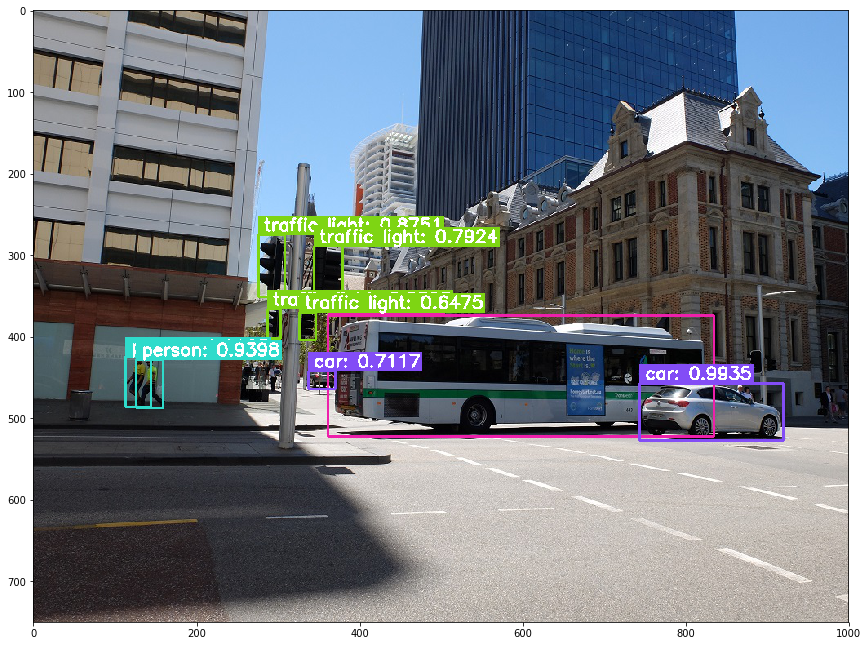

```
['bus: 0.9998', 'car: 0.9935', 'traffic light: 0.8751', 'traffic light: 0.7924', 'traffic light: 0.8595', 'traffic light: 0.6475', 'person: 0.9123', 'person: 0.9398', 'car: 0.7117']
```

```python
print(classes[nms_idx])

# Draw bounding boxes on the image and show

font = cv2.FONT_HERSHEY_SIMPLEX
font_scale = 0.7
border_thickness = 2
text_thickness = 2

text_all = []
for box in nms_idx:
    color = tuple([int(c) for c in COLORS[classes[box]]])
    #print(color)
    text = "{}: {:.4f}".format(LABELS[classes[box]], scores[box])
    #print(text)
    text_all.append(text)

    (pt1_x, pt1_y) = (int(boxes_coord[box, 0]), int(boxes_coord[box, 1]))
    (pt2_x, pt2_y) = (int(boxes_coord[box, 2]), int(boxes_coord[box, 3]))
    cv2.rectangle(image, (pt1_x, pt1_y), (pt2_x, pt2_y), color, border_thickness)

    (t_w, t_h), _ = cv2.getTextSize(text, font, fontScale=font_scale, thickness=text_thickness)
    text_offset_x = 7
    text_offset_y = 7
    (text_box_x1, text_box_y1) = (pt1_x, pt1_y - (t_h + text_offset_y))
    (test_box_x2, text_box_y2) = ((pt1_x + t_w + text_offset_x), pt1_y)

    cv2.rectangle(image, (text_box_x1, text_box_y1), (test_box_x2, text_box_y2), color, cv2.FILLED)

    cv2.putText(image, text, (pt1_x + text_offset_x,pt1_y - 5), cv2.FONT_HERSHEY_SIMPLEX, font_scale,
                                (255, 255, 255), text_thickness)

image = cv2.cvtColor(image, cv2.COLOR_BGR2RGB)

plt.figure(figsize=(w*0.015, h*0.015))

plt.imshow(image)
plt.show()

print(text_all)
```